```python
import math
import os
from tensorflow.keras.datasets import mnist
from tensorflow.keras.models import Sequential
from tensorflow.keras.layers import Dense, LSTM, SimpleRNN
from tensorflow.keras.utils import to_categorical, plot_model
import pandas as pd
from sklearn.preprocessing import StandardScaler
from sklearn.metrics import confusion_matrix, classification_report
import numpy as np
import seaborn as sn
import matplotlib.pyplot as plt
import numpy
```

Tarea Número 4

# Ejercicio 1:

</p> **[20 puntos]** Para una Red Neuronal RNN tipo Vanilla sin sesgo (bias), es decir, $h_t = tanh(W_{hh}h_{t-1} + W_{xh}x_{t})$ y $h_0 = \vec{0}$. Además se tiene que:

$x_1 = \begin{pmatrix} 2 \\ 7 \\ 3 \\ 1 \\ \end{pmatrix}$, $x_2 = \begin{pmatrix} 0 \\ 1 \\ 0 \\ 1 \\ \end{pmatrix}$, $W_{xh} = \begin{pmatrix} 2 & 5 & 0 & 3 \\ 0 & 3 & 8 & 2 \\ 3 & 0 & 1 & 1 \\ 0 & 1 & 2 & 0\\ 1 & 1 & 2 & 1 \end{pmatrix}$, $W_{hh} = \begin{pmatrix} 1 & 0 & 1 & 1 & 2 \\ 1 & 1 & 4 & 1 & 2 \\ 3 & 0 & 1 & 1 & 1\\ 1 & 1 & 2 & 0 & 9\\ 1 & 1 & 1 & 1 & 1 \end{pmatrix}$

1. Calcule $h_1$ y $h_2$
- \begin{align*} h_1 &= tanh(W_{hh}h_{0} + W_{xh}x_{1}) \\ h_1 &= tanh \Bigg ( \begin{pmatrix} 1 & 0 & 1 & 1 & 2 \\ 1 & 1 & 4 & 1 & 2 \\ 3 & 0 & 1 & 1 & 1\\ 1 & 1 & 2 & 0 & 9\\ 1 & 1 & 1 & 1 & 1 \end{pmatrix} \cdot \begin{pmatrix} 0 \\ 0\\ 0 \\ 0\\ 0 \end{pmatrix} + \begin{pmatrix} 2 & 5 & 0 & 3 \\ 0 & 3 & 8 & 2 \\ 3 & 0 & 1 & 1 \\ 0 & 1 & 2 & 0\\ 1 & 1 & 2 & 1 \end{pmatrix} \cdot \begin{pmatrix} 2 \\ 7 \\ 3 \\ 1 \\ \end{pmatrix}\Bigg ) \\ h_1 &= tanh \Bigg ( \begin{pmatrix} 0 \\ 0\\ 0 \\ 0\\ 0 \end{pmatrix} + \begin{pmatrix} 42 \\ 47\\ 10 \\ 13\\ 16 \end{pmatrix} \Bigg ) \\ h_1 &= tanh \Bigg (\begin{pmatrix} 42 \\ 47\\ 10 \\ 13\\ 16 \end{pmatrix} \Bigg ) \\ h_1 &= \begin{pmatrix} 1 \\ 1\\ 0.9999 \\ 0.9999\\ 0.9999 \end{pmatrix} \end{align*}
- \begin{align*} h_2 &= tanh(W_{hh}h_{1} + W_{xh}x_{2}) \\ h_2 &= tanh \Bigg ( \begin{pmatrix} 1 & 0 & 1 & 1 & 2 \\ 1 & 1 & 4 & 1 & 2 \\ 3 & 0 & 1 & 1 & 1\\ 1 & 1 & 2 & 0 & 9\\ 1 & 1 & 1 & 1 & 1 \end{pmatrix} \cdot \begin{pmatrix} 1 \\ 1\\ 0.9999 \\ 0.9999\\ 0.9999 \end{pmatrix} + \begin{pmatrix} 2 & 5 & 0 & 3 \\ 0 & 3 & 8 & 2 \\ 3 & 0 & 1 & 1 \\ 0 & 1 & 2 & 0\\ 1 & 1 & 2 & 1 \end{pmatrix} \cdot \begin{pmatrix} 0 \\ 1 \\ 0 \\ 1 \\ \end{pmatrix}\Bigg ) \\ h_2 &= tanh \Bigg ( \begin{pmatrix} 4.9996 \\ 8.9993\\ 5.9997 \\ 12.9989\\ 4.9997 \end{pmatrix} + \begin{pmatrix} 8 \\ 5\\ 1 \\ 1\\ 2 \end{pmatrix} \Bigg ) \\ h_2 &= tanh \Bigg (\begin{pmatrix} 12.9996 \\ 13.9993\\ 6.9997 \\ 13.9989\\ 6.9997 \end{pmatrix} \Bigg ) \\ h_2 &= \begin{pmatrix} 0.9999 \\ 0.9999\\ 0.9999 \\ 0.9999\\ 0.9999 \end{pmatrix} \end{align*}
1. Prediga $y_2 = W_{hy}h_2$ para $W_{hy}= \begin{pmatrix} 1 & 0 & 1 & 0 & 1 \\ 0 & 1 & 0 & 1 & 1 \end{pmatrix}$

\begin{align*} y_2 &= W_{hy}h_2 \\ y_2 &= \begin{pmatrix} 1 & 0 & 1 & 0 & 1 \\ 0 & 1 & 0 & 1 & 1 \end{pmatrix} \cdot \begin{pmatrix} 1 \\ 1 \\ 1 \\ 1 \\ 1 \end{pmatrix} \\ y_2 &= \begin{pmatrix} 3 \\ 3 \end{pmatrix} \end{align*}

# Ejercicio 2:

</p>

**[20 puntos]** Dada una Red Neuronal RNN tipo LTSM, es decir:

\begin{align*} f_t &= \sigma (W_{hf}h_{t-1} + W_{xf}x_{t}) \\ i_t &= \sigma (W_{hi}h_{t-1} + W_{xi}x_{t}) \\ o_t &= \sigma (W_{ho}h_{t-1} + W_{xo}x_{t}) \\ g_t &= tanh (W_{hg}h_{t-1} + W_{xg}x_{t}) \\ h_0 &= \vec{0} \end{align*}\begin{align*} c_t &= f_t \odot c_{t-1} + i_t \odot g_t\\ h_t &= o_t \odot tanh(c_t) \\ c_0 &= \vec{0} \\ \end{align*}

Además se tiene que:

$x_1 = \begin{pmatrix} 2 \\ 7 \\ 3 \\ 1 \\ \end{pmatrix}$, $x_2 = \begin{pmatrix} 0 \\ 1 \\ 0 \\ 1 \\ \end{pmatrix}$, $W_{xf} = \begin{pmatrix} 2 & 5 & 0 & 3 \\ 0 & 3 & 8 & 2 \\ 3 & 0 & 1 & 1 \\ 0 & 1 & 2 & 0\\ 1 & 1 & 2 & 1 \end{pmatrix}$, $W_{hf} = \begin{pmatrix} 1 & 0 & 1 & 1 & 2 \\ 1 & 1 & 4 & 1 & 2 \\ 3 & 0 & 1 & 1 & 1\\ 1 & 1 & 2 & 0 & 9\\ 1 & 1 & 1 & 1 & 1 \end{pmatrix}$

$$W_{xi} = \begin{pmatrix} 2 & 5 & 0 & 3 \\ 0 & 3 & 8 & 2 \\ 3 & 0 & 1 & 1 \\ 0 & 1 & 2 & 0 \\ 1 & 1 & 2 & 1 \end{pmatrix}, \ \ W_{hi} = \begin{pmatrix} 1 & 0 & 1 & 1 & 2 \\ 1 & 1 & 4 & 1 & 2 \\ 3 & 0 & 1 & 1 & 1\\ 1 & 1 & 2 & 0 & 9\\ 1 & 1 & 1 & 1 & 1 \end{pmatrix}$$$$W_{xo} = \begin{pmatrix} 2 & 0 & 0 & 3 \\ 0 & 3 & 0 & 2 \\ 3 & 0 & 1 & 1 \\ 0 & 1 & 0 & 0 \\ 1 & 1 & 0 & 1 \end{pmatrix}, \ \ W_{ho} = \begin{pmatrix} 1 & 0 & 1 & 1 & 0 \\ 1 & 1 & 0 & 1 & 2 \\ 3 & 0 & 1 & 1 & 1\\ 1 & 1 & 0 & 0 & 9\\ 1 & 1 & 0 & 1 & 1 \end{pmatrix}$$$$W_{xg} = \begin{pmatrix} 2 & 0 & 0 & 0 \\ 0 & 0 & 0 & 2 \\ 0 & 0 & 1 & 1 \\ 0 & 1 & 0 & 0 \\ 1 & 1 & 0 & 1 \end{pmatrix}, \ \ W_{hg} = \begin{pmatrix} 1 & 0 & 0 & 1 & 2 \\ 1 & 1 & 0 & 1 & 2 \\ 0 & 0 & 1 & 1 & 1\\ 1 & 1 & 0 & 0 & 0\\ 1 & 1 & 0 & 1 & 0 \end{pmatrix}$$

1. Calcule $h_1$ y $h_2$
- $h_1$

$h_1 = o_1 \odot tanh(c_1)$

Primero calculemos $c_1$

$c_1 = f_1 \odot c_{0} + i_1 \odot g_1$

Donde \begin{align*} f_1 &= \sigma (W_{hf}h_{0} + W_{xf}x_{1}) \\ &= \sigma \Bigg ( \begin{pmatrix} 1 & 0 & 1 & 1 & 2 \\ 1 & 1 & 4 & 1 & 2 \\ 3 & 0 & 1 & 1 & 1\\ 1 & 1 & 2 & 0 & 9\\ 1 & 1 & 1 & 1 & 1 \end{pmatrix} \cdot \begin{pmatrix} 0 \\ 0 \\ 0 \\ 0 \\ 0 \end{pmatrix} + \begin{pmatrix} 2 & 5 & 0 & 3 \\ 0 & 3 & 8 & 2 \\ 3 & 0 & 1 & 1 \\ 0 & 1 & 2 & 0\\ 1 & 1 & 2 & 1 \end{pmatrix} \cdot \begin{pmatrix} 2 \\ 7 \\ 3 \\ 1 \\ \end{pmatrix} \Bigg ) \\ &= \sigma \Bigg( \begin{pmatrix} 0 \\ 0 \\ 0 \\ 0 \\ 0 \end{pmatrix} + \begin{pmatrix} 42 \\ 47 \\ 10 \\ 13\\ 16 \end{pmatrix} \Bigg ) \\ &= \sigma \Bigg( \begin{pmatrix} 42 \\ 47 \\ 10 \\ 13\\ 16 \end{pmatrix} \Bigg ) \\ &= \begin{pmatrix} 1 \\ 1\\ 0.9999 \\ 0.9999\\ 0.9999 \end{pmatrix} \end{align*}

\begin{align*} i_1 &= \sigma (W_{hi}h_{0} + W_{xi}x_{1}) \\ &= \sigma \Bigg ( \begin{pmatrix} 1 & 0 & 1 & 1 & 2 \\ 1 & 1 & 4 & 1 & 2 \\ 3 & 0 & 1 & 1 & 1\\ 1 & 1 & 2 & 0 & 9\\ 1 & 1 & 1 & 1 & 1 \end{pmatrix} \cdot \begin{pmatrix} 0 \\ 0 \\ 0 \\ 0 \\ 0 \end{pmatrix} + \begin{pmatrix} 2 & 5 & 0 & 3 \\ 0 & 3 & 8 & 2 \\ 3 & 0 & 1 & 1 \\ 0 & 1 & 2 & 0\\ 1 & 1 & 2 & 1 \end{pmatrix} \cdot \begin{pmatrix} 2 \\ 7 \\ 3 \\ 1 \\ \end{pmatrix} \Bigg ) \\ &= \sigma \Bigg( \begin{pmatrix} 0 \\ 0 \\ 0 \\ 0 \\ 0 \end{pmatrix} + \begin{pmatrix} 42 \\ 47 \\ 10 \\ 13\\ 16 \end{pmatrix} \Bigg ) \\ &= \sigma \Bigg( \begin{pmatrix} 42 \\ 47 \\ 10 \\ 13\\ 16 \end{pmatrix} \Bigg ) \\ &= \begin{pmatrix} 1 \\ 1\\ 0.9999 \\ 0.9999\\ 0.9999 \end{pmatrix} \end{align*}

\begin{align*} g_1 &= \tanh (W_{hg}h_{0} + W_{xg}x_{1}) \\ &= \sigma \Bigg ( \begin{pmatrix} 1 & 0 & 0 & 1 & 2 \\ 1 & 1 & 0 & 1 & 2 \\ 0 & 0 & 1 & 1 & 1\\ 1 & 1 & 0 & 0 & 0\\ 1 & 1 & 0 & 1 & 0 \end{pmatrix} \cdot \begin{pmatrix} 0 \\ 0 \\ 0 \\ 0 \\ 0 \end{pmatrix} + \begin{pmatrix} 2 & 0 & 0 & 0 \\ 0 & 0 & 0 & 2 \\ 0 & 0 & 1 & 1 \\ 0 & 1 & 0 & 0\\ 1 & 1 & 0 & 1 \end{pmatrix} \cdot \begin{pmatrix} 2 \\ 7 \\ 3 \\ 1 \\ \end{pmatrix} \Bigg ) \\ &= \sigma \Bigg( \begin{pmatrix} 0 \\ 0 \\ 0 \\ 0 \\ 0 \end{pmatrix} + \begin{pmatrix} 4 \\ 2 \\ 4 \\ 7 \\ 10 \end{pmatrix} \Bigg ) \\ &= \sigma \Bigg( \begin{pmatrix} 4 \\ 2 \\ 4 \\ 7\\ 10 \end{pmatrix} \Bigg ) \\ &= \begin{pmatrix} 0.9820 \\ 0.8807 \\ 0.9820 \\ 0.9990\\ 0.9999 \end{pmatrix} \end{align*}

Entonces \begin{align*} c_1 &= f_1 \odot c_{0} + i_1 \odot g_1 \\ &= \begin{pmatrix} 1 \\ 1\\ 0.9999 \\ 0.9999\\ 0.9999 \end{pmatrix} \odot \begin{pmatrix} 0 \\ 0 \\ 0 \\ 0 \\ 0 \end{pmatrix} + \begin{pmatrix} 1 \\ 1\\ 0.9999 \\ 0.9999\\ 0.9999 \end{pmatrix} \odot \begin{pmatrix} 0.9820 \\ 0.8807 \\ 0.9820 \\ 0.9990\\ 0.9999 \end{pmatrix} \\ &= \begin{pmatrix} 0 \\ 0 \\ 0 \\ 0 \\ 0 \end{pmatrix} + \begin{pmatrix} 0.982 \\ 0.8807 \\ 0.9819 \\ 0.9989 \\ 0.9998 \end{pmatrix} \\ &= \begin{pmatrix} 0.982 \\ 0.8807 \\ 0.9819 \\ 0.9989 \\ 0.9998 \end{pmatrix} \end{align*}

De esta forma $tanh(c_1) = tanh\begin{pmatrix} 0.982 \\ 0.8807 \\ 0.9819 \\ 0.9989 \\ 0.9998 \end{pmatrix}$ $= \begin{pmatrix} 0.7539 \\ 0.7067 \\ 0.7538 \\ 0.7611 \\ 0.7615 \end{pmatrix} $

Ahora calculamos $o_1$

\begin{align*} o_1 &= \sigma (W_{ho}h_{0} + W_{xo}x_{1}) \\ &= \sigma \Bigg (\begin{pmatrix} 1 & 0 & 1 & 1 & 0 \\ 1 & 1 & 0 & 1 & 2 \\ 3 & 0 & 1 & 1 & 1\\ 1 & 1 & 0 & 0 & 9\\ 1 & 1 & 0 & 1 & 1 \end{pmatrix} \cdot \begin{pmatrix} 0 \\ 0 \\ 0 \\ 0 \\ 0 \end{pmatrix} + \begin{pmatrix} 2 & 0 & 0 & 3 \\ 0 & 3 & 0 & 2 \\ 3 & 0 & 1 & 1 \\ 0 & 1 & 0 & 0 \\ 1 & 1 & 0 & 1 \end{pmatrix} \cdot \begin{pmatrix} 2 \\ 7 \\ 3 \\ 1 \\ \end{pmatrix} \Bigg ) \\ & = \sigma \Bigg (\begin{pmatrix} 0 \\ 0 \\ 0 \\ 0 \\ 0 \end{pmatrix} + \begin{pmatrix} 7 \\ 23 \\ 10 \\ 7 \\ 10 \end{pmatrix} \Bigg ) \\ & = \sigma \Bigg ( \begin{pmatrix} 7 \\ 23 \\ 10 \\ 7 \\ 10 \end{pmatrix} \Bigg ) \\ & = \begin{pmatrix} 0.9990 \\ 0.9999 \\ 0.9999 \\ 0.9990 \\ 0.9999 \end{pmatrix} \end{align*}

Finalmente $h_1 = o_1 \odot tanh(c_1) = \begin{pmatrix} 0.9990 \\ 0.9999 \\ 0.9999 \\ 0.9990 \\ 0.9999 \end{pmatrix} \odot \begin{pmatrix} 0.7539 \\ 0.7067 \\ 0.7538 \\ 0.7611 \\ 0.7615 \end{pmatrix} = \begin{pmatrix} 0.7531 \\ 0.7066 \\ 0.7537 \\ 0.7603 \\ 0.7614 \end{pmatrix} $

- $h_2$

$h_2 = o_2 \odot tanh(c_2)$

Primero calculemos $c_2$

$c_2 = f_2 \odot c_{1} + i_2 \odot g_2$

Donde \begin{align*} f_2 &= \sigma (W_{hf}h_{1} + W_{xf}x_{2}) \\ &= \sigma \Bigg ( \begin{pmatrix} 1 & 0 & 1 & 1 & 2 \\ 1 & 1 & 4 & 1 & 2 \\ 3 & 0 & 1 & 1 & 1\\ 1 & 1 & 2 & 0 & 9\\ 1 & 1 & 1 & 1 & 1 \end{pmatrix} \cdot \begin{pmatrix} 0.7531 \\ 0.7066 \\ 0.7537 \\ 0.7603 \\ 0.7614 \end{pmatrix} + \begin{pmatrix} 2 & 5 & 0 & 3 \\ 0 & 3 & 8 & 2 \\ 3 & 0 & 1 & 1 \\ 0 & 1 & 2 & 0\\ 1 & 1 & 2 & 1 \end{pmatrix} \cdot \begin{pmatrix} 0 \\ 1 \\ 0 \\ 1 \\ \end{pmatrix} \Bigg ) \\ &= \sigma \Bigg( \begin{pmatrix} 3.7899 \\ 6.7576 \\ 4.5347 \\ 9.8197 \\ 3.7351 \end{pmatrix} + \begin{pmatrix} 8\\ 5 \\ 1 \\ 1\\ 2 \end{pmatrix} \Bigg ) \\ &= \sigma \Bigg( \begin{pmatrix} 11.7899 \\ 11.7576 \\ 5.5347 \\ 10.8197\\ 5.7351 \end{pmatrix} \Bigg ) \\ &= \begin{pmatrix} 0.9999 \\ 0.9999\\ 0.9960 \\ 0.9999\\ 0.9967 \end{pmatrix} \end{align*}

\begin{align*} i_2 &= \sigma (W_{hi}h_{1} + W_{xi}x_{2}) \\ &= \sigma \Bigg ( \begin{pmatrix} 1 & 0 & 1 & 1 & 2 \\ 1 & 1 & 4 & 1 & 2 \\ 3 & 0 & 1 & 1 & 1\\ 1 & 1 & 2 & 0 & 9\\ 1 & 1 & 1 & 1 & 1 \end{pmatrix} \cdot \begin{pmatrix} 0.7531 \\ 0.7066 \\ 0.7537 \\ 0.7603 \\ 0.7614 \end{pmatrix} + \begin{pmatrix} 2 & 5 & 0 & 3 \\ 0 & 3 & 8 & 2 \\ 3 & 0 & 1 & 1 \\ 0 & 1 & 2 & 0\\ 1 & 1 & 2 & 1 \end{pmatrix} \cdot \begin{pmatrix} 0 \\ 1 \\ 0 \\ 1 \\ \end{pmatrix} \Bigg ) \\ &= \sigma \Bigg( \begin{pmatrix} 3.7899 \\ 6.7576 \\ 4.5347 \\ 9.8197 \\ 3.7351 \end{pmatrix} + \begin{pmatrix} 8 \\ 5 \\ 1 \\ 1\\ 2 \end{pmatrix} \Bigg ) \\ &= \sigma \Bigg( \begin{pmatrix} 11.7899 \\ 11.7576 \\ 5.5347 \\ 10.8197\\ 5.7351 \end{pmatrix} \Bigg ) \\ &= \begin{pmatrix} 0.9999 \\ 0.9999\\ 0.9960 \\ 0.9999\\ 0.9967 \end{pmatrix} \end{align*}

\begin{align*} g_2 &= \tanh (W_{hg}h_{1} + W_{xg}x_{2}) \\ &= \sigma \Bigg ( \begin{pmatrix} 1 & 0 & 0 & 1 & 2 \\ 1 & 1 & 0 & 1 & 2 \\ 0 & 0 & 1 & 1 & 1\\ 1 & 1 & 0 & 0 & 0\\ 1 & 1 & 0 & 1 & 0 \end{pmatrix} \cdot \begin{pmatrix} 0.7531 \\ 0.7066 \\ 0.7537 \\ 0.7603 \\ 0.7614 \end{pmatrix} + \begin{pmatrix} 2 & 0 & 0 & 0 \\ 0 & 0 & 0 & 2 \\ 0 & 0 & 1 & 1 \\ 0 & 1 & 0 & 0\\ 1 & 1 & 0 & 1 \end{pmatrix} \cdot \begin{pmatrix} 0 \\ 1 \\ 0 \\ 1 \\ \end{pmatrix} \Bigg ) \\ &= \sigma \Bigg( \begin{pmatrix} 3.0362 \\ 3.7428 \\ 2.2754 \\ 1.4597 \\ 2.22 \end{pmatrix} + \begin{pmatrix} 0 \\ 2 \\ 1 \\ 1 \\ 2 \end{pmatrix} \Bigg ) \\ &= \sigma \Bigg( \begin{pmatrix} 3.0362 \\ 5.7428 \\ 3.2754 \\ 2.4597 \\ 4.22 \end{pmatrix} \Bigg ) \\ &= \begin{pmatrix} 0.9541 \\ 0.9968 \\ 0.9635 \\ 0.9212\\ 0.9855 \end{pmatrix} \end{align*}

Entonces \begin{align*} c_2 &= f_2 \odot c_{1} + i_2 \odot g_2 \\ &= \begin{pmatrix} 0.9999 \\ 0.9999\\ 0.9960 \\ 0.9999\\ 0.9967 \end{pmatrix} \odot \begin{pmatrix} 0.982 \\ 0.8807 \\ 0.9819 \\ 0.9989 \\ 0.9998 \end{pmatrix} + \begin{pmatrix} 0.9999 \\ 0.9999\\ 0.9960 \\ 0.9999\\ 0.9967 \end{pmatrix} \odot \begin{pmatrix} 0.9541 \\ 0.9968 \\ 0.9635 \\ 0.9212\\ 0.9855 \end{pmatrix} \\ &= \begin{pmatrix} 0.9819 \\ 0.8806 \\ 0.9779 \\ 0.9988 \\ 0.9934 \end{pmatrix} + \begin{pmatrix} 0.9540 \\ 0.9967 \\ 0.9596\\ 0.9211 \\ 0.9822 \end{pmatrix} \\ &= \begin{pmatrix} 1.9359 \\ 1.8773 \\ 1.9375 \\ 1.9199 \\ 1.9756 \end{pmatrix} \end{align*}

De esta forma $tanh(c_2) = tanh\begin{pmatrix} 1.9359 \\ 1.8773 \\ 1.9375 \\ 1.9199 \\ 1.9756 \end{pmatrix}$ $= \begin{pmatrix} 0.9359 \\ 0.9542 \\ 0.9593 \\ 0.9579 \\ 0.9622 \end{pmatrix} $

Ahora calculamos $o_2$

\begin{align*} o_2 &= \sigma (W_{ho}h_{1} + W_{xo}x_{2}) \\ &= \sigma \Bigg (\begin{pmatrix} 1 & 0 & 1 & 1 & 0 \\ 1 & 1 & 0 & 1 & 2 \\ 3 & 0 & 1 & 1 & 1\\ 1 & 1 & 0 & 0 & 9\\ 1 & 1 & 0 & 1 & 1 \end{pmatrix} \cdot \begin{pmatrix} 0.7531 \\ 0.7066 \\ 0.7537 \\ 0.7603 \\ 0.7614 \end{pmatrix} + \begin{pmatrix} 2 & 0 & 0 & 3 \\ 0 & 3 & 0 & 2 \\ 3 & 0 & 1 & 1 \\ 0 & 1 & 0 & 0 \\ 1 & 1 & 0 & 1 \end{pmatrix} \cdot \begin{pmatrix} 0 \\ 1 \\ 0 \\ 1 \\ \end{pmatrix} \Bigg ) \\ & = \sigma \Bigg (\begin{pmatrix} 2.2671 \\ 3.7428 \\ 4.5347 \\ 8.3123 \\ 2.9814 \end{pmatrix} + \begin{pmatrix} 3 \\ 5 \\ 1 \\ 1 \\ 2 \end{pmatrix} \Bigg ) \\ & = \sigma \Bigg ( \begin{pmatrix} 5.2671 \\ 8.7428 \\ 5.5347 \\ 9.3123 \\ 4.9814 \end{pmatrix} \Bigg ) \\ & = \begin{pmatrix} 0.9948 \\ 0.9998 \\ 0.9960 \\ 0.9999 \\ 0.9931 \end{pmatrix} \end{align*}

Finalmente $h_2 = o_2 \odot tanh(c_2) = \begin{pmatrix} 0.9948 \\ 0.9998 \\ 0.9960 \\ 0.9999 \\ 0.9931 \end{pmatrix} \odot \begin{pmatrix} 0.9359 \\ 0.9542 \\ 0.9593 \\ 0.9579 \\ 0.9622 \end{pmatrix} = \begin{pmatrix} 0.9310 \\ 0.9540 \\ 0.9554 \\ 0.9578 \\ 0.9555 \end{pmatrix} $

```python
def tanh(x):
    return (math.exp(x)- math.exp(-x))/(math.exp(x)+math.exp(-x))

tanh(2.9991)
```

```
0.9950458662965854
```

# Ejercicio 3

</p>

**[30 puntos]** En este ejercicio usaremos las acciones de diferentes empresas disponibles en `yahoo`, publicadas en el siguiente enlace:

```
https://es-us.finanzas.yahoo.com/
```

Elija una empresa de su interés y utilicela para el realizar el modelo y los siguientes ejercicios.

Realice lo siguiente:

1. Descargue los precios de los datos históricos de enero del 2015 hasta diciembre del 2020, en frecuencia diaria.
1. Cargue los datos y asegurese de agregar el parámetro parse `dates=[’Date’]`.

```python
dataset = pd.read_csv('AAPL.csv',delimiter=",",decimal=".", index_col=0,parse_dates=['Date'])
print(dataset.shape)
dataset.head()
```

```
(1510, 6)
```

| Date | Open | High | Low | Close | Adj Close | Volume |
| --- | --- | --- | --- | --- | --- | --- |
| 2015-01-02 | 27.847500 | 27.860001 | 26.837500 | 27.332500 | 24.782110 | 212818400 |
| 2015-01-05 | 27.072500 | 27.162500 | 26.352501 | 26.562500 | 24.083958 | 257142000 |
| 2015-01-06 | 26.635000 | 26.857500 | 26.157499 | 26.565001 | 24.086227 | 263188400 |
| 2015-01-07 | 26.799999 | 27.049999 | 26.674999 | 26.937500 | 24.423975 | 160423600 |
| 2015-01-08 | 27.307501 | 28.037500 | 27.174999 | 27.972500 | 25.362394 | 237458000 |

1. Utilice para el `training` los datos desde enero 2015 hasta diciembre del 2018 y para `testing` los datos del 2019. Seleccione la columna `High`.

```python
training = dataset[:'2018'].iloc[:,1:2]
testing = dataset['2019'].iloc[:,1:2]
```

1. Escale los datos de `training`.

```python
scaler = StandardScaler()
sc_training = scaler.fit_transform(training)
sc_training
```

```
array([[-0.86963781],
       [-0.94848922],
       [-0.982969  ],
       ...,
       [ 0.41148386],
       [ 0.46094256],
       [ 0.48468263]])
```

1. Tome bloques de 5 datos consecutivos para entrenar la red y que el dato “6” sea usado como la salida de la red.

```python
time_step = 5

X_train = []
Y_train = []

m = len(sc_training)

for i in range(time_step,m):
    # X: bloques de "time_step" datos: 0-time_step, 1-time_step+1, 2-time_step+2, etc
    X_train.append(sc_training[i-time_step:i,0])

    # Y: el siguiente dato
    Y_train.append(sc_training[i,0])

X_train, Y_train = np.array(X_train), np.array(Y_train)
```

1. Escale los datos de testing y reordenelos como bloques también.

```python
x_test = testing.values
x_test = scaler.transform(x_test)

X_test = []
for i in range(time_step,len(x_test)):
    X_test.append(x_test[i-time_step:i,0])
X_test = np.array(X_test)
X_test = np.reshape(X_test, (X_test.shape[0],X_test.shape[1],1))

X_train = np.reshape(X_train, (X_train.shape[0], X_train.shape[1], 1))
```

1. Definir el tamaño de los datos de entrada y del dato de salida, así como el número total de neuronas.

```python
dim_entrada = (X_train.shape[1],1)
dim_salida = 1
na = 50
```

1. Haga el modelo usando la función de activación `relu` y con las capas que considere necesarias. Utilice la función de optimización `adam`, la función de costo `mse`.

```python
modelo = Sequential()

modelo.add(LSTM(units=na, input_shape=dim_entrada))
modelo.add(Dense(units=dim_salida, activation='relu'))

modelo.compile(optimizer='adam', loss='mse')
```

1. Haga un resumen del modelo

```python
#resumen del modelo
modelo.summary()
```

```
Model: "sequential_1"
_________________________________________________________________
Layer (type)                 Output Shape              Param #
=================================================================
lstm_1 (LSTM)                (None, 50)                10400
_________________________________________________________________
dense_1 (Dense)              (None, 1)                 51
=================================================================
Total params: 10,451
Trainable params: 10,451
Non-trainable params: 0
_________________________________________________________________
```

1. Entrene el modelo usando un tamaño de bloque de 32 y 500 `epochs`.

```python
modelo.fit(X_train,Y_train,epochs=500,batch_size=32)
```

```
<tensorflow.python.keras.callbacks.History at 0x7fec368f2430>
```

1. Genere las predicciones y para interpretar la calidad de las mismas grafique los resultados. En el gráfico incluya los datos de entrenamiento, los de prueba y los que el modelo predijo.

```python
prediccion = modelo.predict(X_test)

# aplicamos la normalización inversa de dicha predicción
prediccion = scaler.inverse_transform(prediccion)
```

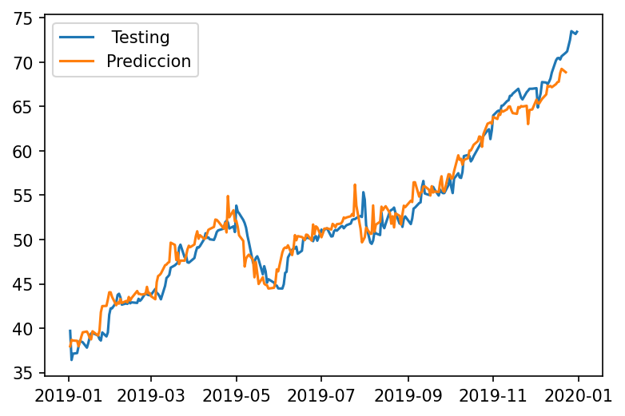

```python
#Gráfico
fig, ax = plt.subplots(1,1, figsize = (6,4), dpi = 150)

plt.plot(testing.index, testing.values, label = " Testing")
plt.plot(testing.index[0:len(X_test)], prediccion, label = "Prediccion")

plt.legend()
```

# Ejercicio 4:

</p>

**[30 puntos]** En este ejercicio vamos a intentar predecir la letra que sigue del alfabeto griego. Cabe resaltar que no existe un mapeo exacto del abecedario al nuestro y que el número de letras es inferior al nuestro también.

Copie y pegue el siguiente código y utilicelo cómo set de datos.

```
`alfabetoGriego` = ”αβγδεζηθικλμνξøπρστυφχψω”
```

Para esto realice lo siguiente:

1. Defina un conjunto con los diferentes caracteres que conforman el `set`.

```python
alfabetoGriego = "αβγδεζηθικλμνξøπρστυφχψω"
```

1. Cree un diccionario que permita definir la equivalencia entre caracter e índice, así como su inverso.

```python
char_to_int = dict((c, i) for i, c in enumerate(alfabetoGriego))
int_to_char = dict((i, c) for i, c in enumerate(alfabetoGriego ))
```

1. Haga los pares de entrada y salida para entrenar el modelo y transforme al formato esperado por la red.

```python
seq_length = 1
dataX = []
dataY = []

for i in range(0, len(alfabetoGriego) - seq_length):
    seq_in = alfabetoGriego[i:i + seq_length]
    seq_out = alfabetoGriego[i + seq_length]
    dataX.append([char_to_int[char] for char in seq_in])
    dataY.append(char_to_int[seq_out])
    print(seq_in, '->', seq_out)


X = numpy.reshape(dataX, (len(dataX), seq_length, 1))
```

```
α ->; β
β ->; γ
γ ->; δ
δ ->; ε
ε ->; ζ
ζ ->; η
η ->; θ
θ ->; ι
ι ->; κ
κ ->; λ
λ ->; μ
μ ->; ν
ν ->; ξ
ξ ->; ø
ø ->; π
π ->; ρ
ρ ->; σ
σ ->; τ
τ ->; υ
υ ->; φ
φ ->; χ
χ ->; ψ
ψ ->; ω
```

1. Normalice los datos y trasforme la variable a predecir a formato ’One-Hot’.

```python
X = X / float(len(alfabetoGriego))

y = to_categorical(dataY)
```

1. Haga el modelo usando la función de activación `softmax` y con las capas que considere necesarias. Utilice la función de optimización `RMSProp`, la función de costo `categorical_crossentropy` y las métricas `accuracy`.

```python
modelo = Sequential()

modelo.add(LSTM(32, input_shape=(X.shape[1], X.shape[2])))
modelo.add(Dense(y.shape[1], activation='softmax'))
modelo.compile(loss='categorical_crossentropy', optimizer='RMSProp', metrics=['accuracy'])
```

1. Haga un resumen del modelo.

```python
modelo.summary()
```

```
Model: "sequential_2"
_________________________________________________________________
Layer (type)                 Output Shape              Param #
=================================================================
lstm_2 (LSTM)                (None, 32)                4352
_________________________________________________________________
dense_2 (Dense)              (None, 24)                792
=================================================================
Total params: 5,144
Trainable params: 5,144
Non-trainable params: 0
_________________________________________________________________
```

1. Haga una predicción entrenando el modelo con 500 `epochs` y un tamaño de lote igual a 1.

```python
modelo.fit(X,y, epochs = 500, batch_size=1,verbose=2)
```

```
<tensorflow.python.keras.callbacks.History at 0x7fec1b0e3190>
```

1. Genere la matriz de confusión.

```python
modelo_pred = modelo.predict(X,verbose=0)
rnn_modelo_predicted = np.argmax(modelo_pred, axis=1)

rnn_modelo_cm = confusion_matrix(np.argmax(y, axis=1), rnn_modelo_predicted)

rnn_modelo_df_cm = pd.DataFrame(rnn_modelo_cm, range(23), range(23))
rnn_modelo_df_cm
```

|  | 0 | 1 | 2 | 3 | 4 | 5 | 6 | 7 | 8 | 9 | ... | 13 | 14 | 15 | 16 | 17 | 18 | 19 | 20 | 21 | 22 |
| --- | --- | --- | --- | --- | --- | --- | --- | --- | --- | --- | --- | --- | --- | --- | --- | --- | --- | --- | --- | --- | --- |
| 0 | 1 | 0 | 0 | 0 | 0 | 0 | 0 | 0 | 0 | 0 | ... | 0 | 0 | 0 | 0 | 0 | 0 | 0 | 0 | 0 | 0 |
| 1 | 0 | 1 | 0 | 0 | 0 | 0 | 0 | 0 | 0 | 0 | ... | 0 | 0 | 0 | 0 | 0 | 0 | 0 | 0 | 0 | 0 |
| 2 | 0 | 0 | 1 | 0 | 0 | 0 | 0 | 0 | 0 | 0 | ... | 0 | 0 | 0 | 0 | 0 | 0 | 0 | 0 | 0 | 0 |
| 3 | 0 | 0 | 0 | 1 | 0 | 0 | 0 | 0 | 0 | 0 | ... | 0 | 0 | 0 | 0 | 0 | 0 | 0 | 0 | 0 | 0 |
| 4 | 0 | 0 | 0 | 0 | 1 | 0 | 0 | 0 | 0 | 0 | ... | 0 | 0 | 0 | 0 | 0 | 0 | 0 | 0 | 0 | 0 |
| 5 | 0 | 0 | 0 | 0 | 0 | 1 | 0 | 0 | 0 | 0 | ... | 0 | 0 | 0 | 0 | 0 | 0 | 0 | 0 | 0 | 0 |
| 6 | 0 | 0 | 0 | 0 | 0 | 0 | 1 | 0 | 0 | 0 | ... | 0 | 0 | 0 | 0 | 0 | 0 | 0 | 0 | 0 | 0 |
| 7 | 0 | 0 | 0 | 0 | 0 | 0 | 0 | 1 | 0 | 0 | ... | 0 | 0 | 0 | 0 | 0 | 0 | 0 | 0 | 0 | 0 |
| 8 | 0 | 0 | 0 | 0 | 0 | 0 | 0 | 1 | 0 | 0 | ... | 0 | 0 | 0 | 0 | 0 | 0 | 0 | 0 | 0 | 0 |
| 9 | 0 | 0 | 0 | 0 | 0 | 0 | 0 | 0 | 0 | 1 | ... | 0 | 0 | 0 | 0 | 0 | 0 | 0 | 0 | 0 | 0 |
| 10 | 0 | 0 | 0 | 0 | 0 | 0 | 0 | 0 | 0 | 0 | ... | 0 | 0 | 0 | 0 | 0 | 0 | 0 | 0 | 0 | 0 |
| 11 | 0 | 0 | 0 | 0 | 0 | 0 | 0 | 0 | 0 | 0 | ... | 0 | 0 | 0 | 0 | 0 | 0 | 0 | 0 | 0 | 0 |
| 12 | 0 | 0 | 0 | 0 | 0 | 0 | 0 | 0 | 0 | 0 | ... | 0 | 0 | 0 | 0 | 0 | 0 | 0 | 0 | 0 | 0 |
| 13 | 0 | 0 | 0 | 0 | 0 | 0 | 0 | 0 | 0 | 0 | ... | 1 | 0 | 0 | 0 | 0 | 0 | 0 | 0 | 0 | 0 |
| 14 | 0 | 0 | 0 | 0 | 0 | 0 | 0 | 0 | 0 | 0 | ... | 0 | 1 | 0 | 0 | 0 | 0 | 0 | 0 | 0 | 0 |
| 15 | 0 | 0 | 0 | 0 | 0 | 0 | 0 | 0 | 0 | 0 | ... | 0 | 0 | 0 | 1 | 0 | 0 | 0 | 0 | 0 | 0 |
| 16 | 0 | 0 | 0 | 0 | 0 | 0 | 0 | 0 | 0 | 0 | ... | 0 | 0 | 0 | 1 | 0 | 0 | 0 | 0 | 0 | 0 |
| 17 | 0 | 0 | 0 | 0 | 0 | 0 | 0 | 0 | 0 | 0 | ... | 0 | 0 | 0 | 0 | 0 | 1 | 0 | 0 | 0 | 0 |
| 18 | 0 | 0 | 0 | 0 | 0 | 0 | 0 | 0 | 0 | 0 | ... | 0 | 0 | 0 | 0 | 0 | 0 | 0 | 1 | 0 | 0 |
| 19 | 0 | 0 | 0 | 0 | 0 | 0 | 0 | 0 | 0 | 0 | ... | 0 | 0 | 0 | 0 | 0 | 0 | 0 | 0 | 0 | 1 |
| 20 | 0 | 0 | 0 | 0 | 0 | 0 | 0 | 0 | 0 | 0 | ... | 0 | 0 | 0 | 0 | 0 | 0 | 0 | 0 | 0 | 1 |
| 21 | 0 | 0 | 0 | 0 | 0 | 0 | 0 | 0 | 0 | 0 | ... | 0 | 0 | 0 | 0 | 0 | 0 | 0 | 0 | 0 | 1 |
| 22 | 0 | 0 | 0 | 0 | 0 | 0 | 0 | 0 | 0 | 0 | ... | 0 | 0 | 0 | 0 | 0 | 0 | 0 | 0 | 0 | 1 |

23 rows × 23 columns

1. Calcule la precisión global. Interprete la calidad de los resultados.

```python
scores = modelo.evaluate(X, y, verbose=0)
print("Precisión del modelo: %.2f%%" % (scores[1]*100))
```

```
Precisión del modelo: 60.87%
```

1. Repita el ejercicio 5 pero esta vez utilice como optimizador la función `adam`. Compare resultados.

```python
modelo = Sequential()

modelo.add(LSTM(32, input_shape=(X.shape[1], X.shape[2])))
modelo.add(Dense(y.shape[1], activation='softmax'))
modelo.compile(loss='categorical_crossentropy', optimizer='adam', metrics=['accuracy'])
```

```python
modelo.fit(X,y, epochs = 500, batch_size=1,verbose=2)
```

```
23/23 - 1s - loss: 3.1882 - accuracy: 0.0435
23/23 - 0s - loss: 3.1604 - accuracy: 0.0435
23/23 - 0s - loss: 3.1447 - accuracy: 0.0435
23/23 - 0s - loss: 3.1310 - accuracy: 0.0435
23/23 - 0s - loss: 3.1165 - accuracy: 0.0435
23/23 - 0s - loss: 3.1026 - accuracy: 0.0435
23/23 - 0s - loss: 3.0881 - accuracy: 0.0435
23/23 - 0s - loss: 3.0719 - accuracy: 0.0870
23/23 - 0s - loss: 3.0577 - accuracy: 0.1304
23/23 - 0s - loss: 3.0421 - accuracy: 0.1304
23/23 - 0s - loss: 3.0258 - accuracy: 0.1304
23/23 - 0s - loss: 3.0126 - accuracy: 0.0870
23/23 - 0s - loss: 2.9967 - accuracy: 0.0870
23/23 - 0s - loss: 2.9834 - accuracy: 0.0870
23/23 - 0s - loss: 2.9685 - accuracy: 0.0870
23/23 - 0s - loss: 2.9564 - accuracy: 0.0870
23/23 - 0s - loss: 2.9424 - accuracy: 0.1304
23/23 - 0s - loss: 2.9300 - accuracy: 0.1304
23/23 - 0s - loss: 2.9161 - accuracy: 0.1304
23/23 - 0s - loss: 2.9038 - accuracy: 0.1304
23/23 - 0s - loss: 2.8898 - accuracy: 0.1304
23/23 - 0s - loss: 2.8788 - accuracy: 0.1304
23/23 - 0s - loss: 2.8676 - accuracy: 0.0870
23/23 - 0s - loss: 2.8547 - accuracy: 0.0870
23/23 - 0s - loss: 2.8427 - accuracy: 0.0870
23/23 - 0s - loss: 2.8303 - accuracy: 0.0870
23/23 - 0s - loss: 2.8184 - accuracy: 0.0870
23/23 - 0s - loss: 2.8063 - accuracy: 0.1304
23/23 - 0s - loss: 2.7961 - accuracy: 0.0870
23/23 - 0s - loss: 2.7822 - accuracy: 0.1739
23/23 - 0s - loss: 2.7735 - accuracy: 0.1739
23/23 - 0s - loss: 2.7587 - accuracy: 0.2174
23/23 - 0s - loss: 2.7476 - accuracy: 0.1739
23/23 - 0s - loss: 2.7345 - accuracy: 0.1739
23/23 - 0s - loss: 2.7229 - accuracy: 0.2174
23/23 - 0s - loss: 2.7124 - accuracy: 0.2174
23/23 - 0s - loss: 2.6994 - accuracy: 0.2174
23/23 - 0s - loss: 2.6885 - accuracy: 0.1739
23/23 - 0s - loss: 2.6764 - accuracy: 0.1739
23/23 - 0s - loss: 2.6659 - accuracy: 0.2174
```

[output cut: 445 more lines]

```
23/23 - 0s - loss: 1.4502 - accuracy: 0.6957
23/23 - 0s - loss: 1.4469 - accuracy: 0.7391
23/23 - 0s - loss: 1.4475 - accuracy: 0.6957
23/23 - 0s - loss: 1.4444 - accuracy: 0.7391
23/23 - 0s - loss: 1.4468 - accuracy: 0.6522
23/23 - 0s - loss: 1.4426 - accuracy: 0.7391
23/23 - 0s - loss: 1.4469 - accuracy: 0.6522
23/23 - 0s - loss: 1.4443 - accuracy: 0.7391
23/23 - 0s - loss: 1.4392 - accuracy: 0.6957
23/23 - 0s - loss: 1.4409 - accuracy: 0.7826
23/23 - 0s - loss: 1.4395 - accuracy: 0.6522
23/23 - 0s - loss: 1.4397 - accuracy: 0.6957
23/23 - 0s - loss: 1.4390 - accuracy: 0.6087
23/23 - 0s - loss: 1.4358 - accuracy: 0.7391
23/23 - 0s - loss: 1.4367 - accuracy: 0.7826
```

```
<tensorflow.python.keras.callbacks.History at 0x7fec205e6d90>
```

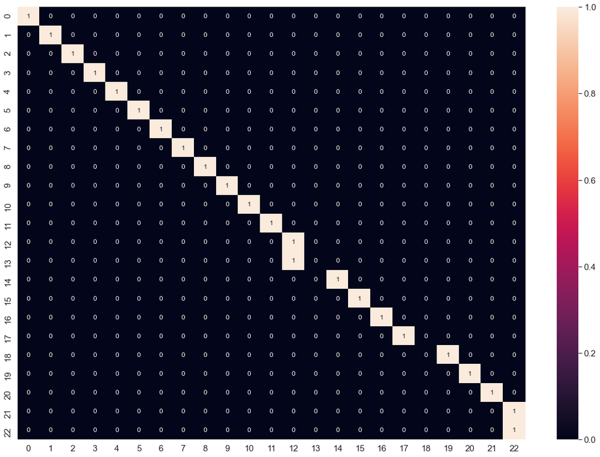

```python
modelo_pred = modelo.predict(X, verbose=0)
rnn_modelo_predicted = np.argmax(modelo_pred, axis=1)

rnn_modelo_cm = confusion_matrix(np.argmax(y, axis=1), rnn_modelo_predicted)

rnn_modelo_df_cm = pd.DataFrame(rnn_modelo_cm, range(23), range(23))
plt.figure(figsize = (20,14))
sn.set(font_scale=1.4) #for label size
sn.heatmap(rnn_modelo_df_cm, annot=True, annot_kws={"size": 12}) # font size
plt.show()
```

```python
scores = modelo.evaluate(X, y, verbose=0)
print("Precisión del modelo: %.2f%%" % (scores[1]*100))
```

```
Precisión del modelo: 78.26%
```